# Plotting continous data in R with ggplot2

## Boxplot with qplot

### Basic boxplot with qplot

- note use of arguement **“geom = …”**

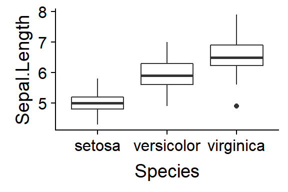

```r
qplot(y = Sepal.Length,
      x = Species,
        data = iris,
      geom = "boxplot")
```

## Basic boxplot with colors

- same as before, using “color =”

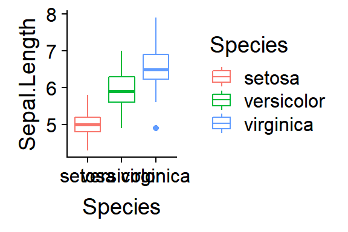

```r
#dopt w/color changes
qplot(y = Sepal.Length,
      x = Species,
        data = iris,
      geom = "boxplot",
      color = Species)
```

## Basic boxplot lables

- now use + xlab() and + ylab()

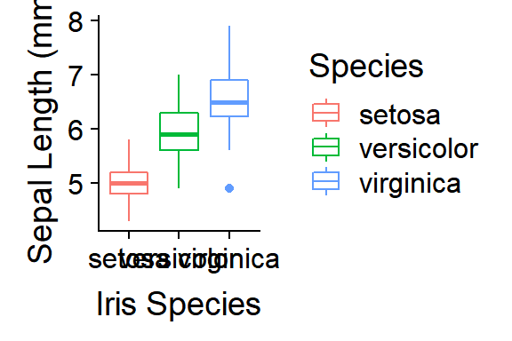

```r
qplot(y = Sepal.Length,
      x = Species,
        data = iris,
      geom = "boxplot",
      color = Species) +
  xlab("Iris Species") +
  ylab ("Sepal Length (mm)")
```

## Histograms using qplot

- made with geom = “histogram” arguement
- very very easy to make in R with ggplot
- very very very hard to make in Excel
- You should make them all the time for you data!

### Histograms of iris data

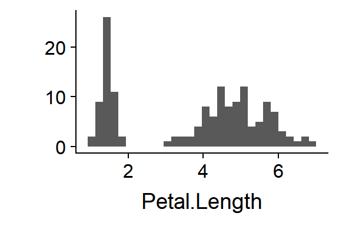

```r
qplot(Petal.Length,
      data = iris)
```

### Histogram with colors

What does this show?

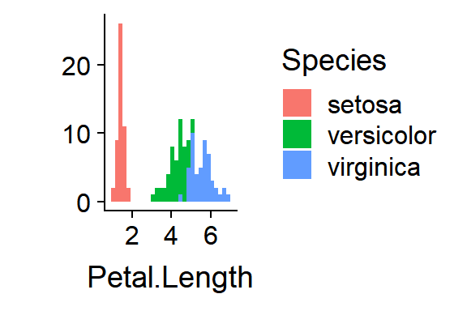

```r
qplot(Petal.Length,
      data = iris,
      fill = Species)
```

### Histogram with axes labels

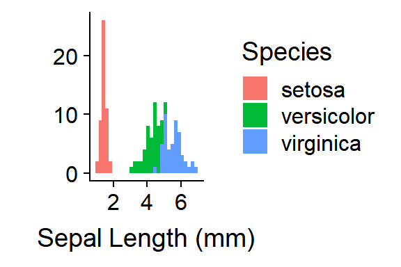

```r
qplot(Petal.Length,
      data = iris,
      fill = Species) +
  xlab ("Sepal Length (mm)")
```

### Multiple histograms: “Facets”

What does this show?

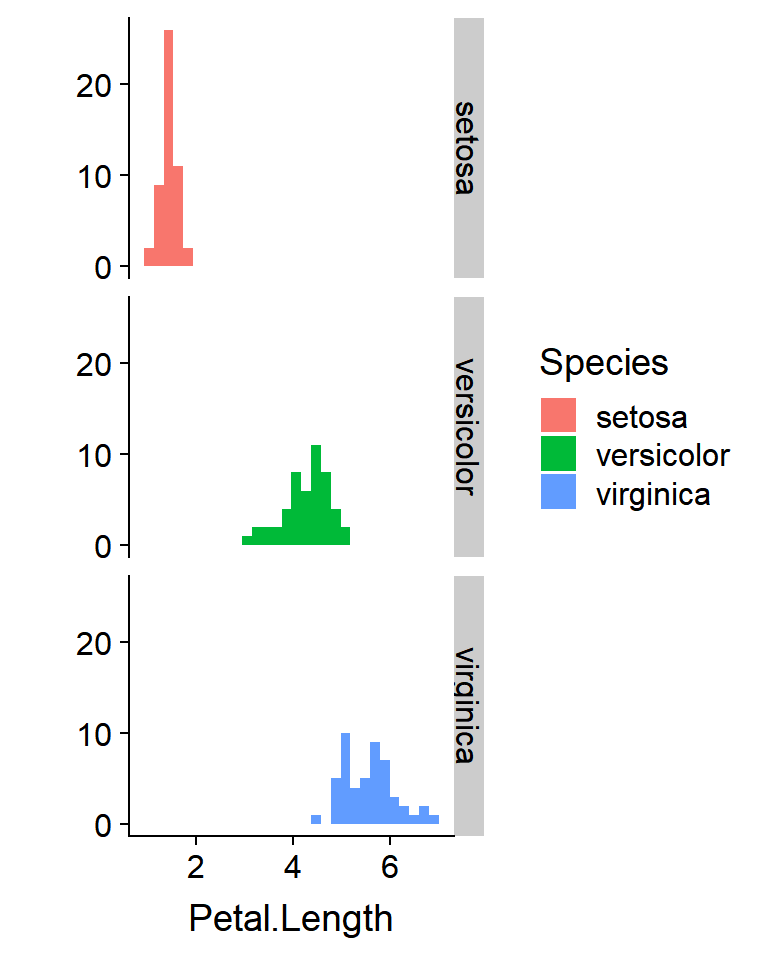

```r
qplot(Petal.Length,
      data = iris,
      fill = Species,
      facets = Species ~.)
```

Add a label to x-axis

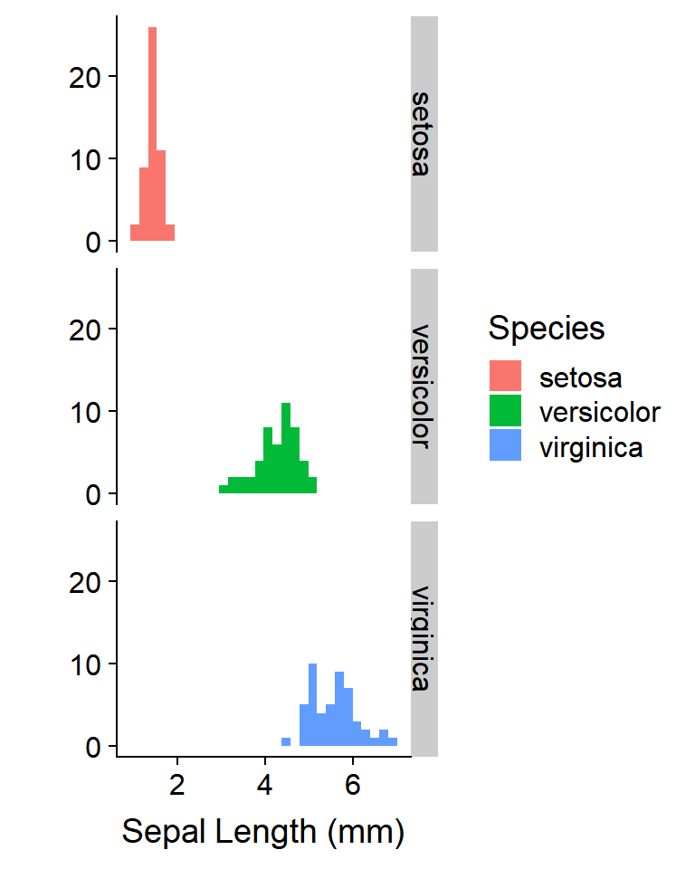

```r
qplot(Petal.Length,
      data = iris,
      fill = Species,
      facets = Species ~.) +
  xlab("Sepal Length (mm)")
```

## Modifying histograms: titles with the main = argument

- Titles are good for your own personal use but actually are almost never used in figures published in papers and books.
- We can add a title like this using the arguement “main =”

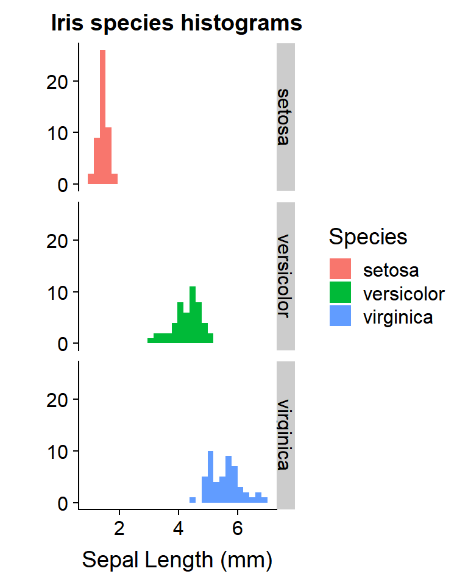

```r
qplot(Petal.Length,
      data = iris,
      fill = Species,
      main = "Iris species histograms",
      facets = Species ~.) +
  xlab ("Sepal Length (mm)")
```